# Part II - Trend of Bike Sharing Data

## by KhoiVN

## Investigation Overview

> The goal of this presentation is to show the trend of bike sharing data in February 2019. The main focus is on the trip duration, the information of users, and the number of trips by user type.

## Dataset Overview

> The data set includes information about individual rides made in a bike-sharing system covering the greater San Francisco Bay area. The data consists of 183,412 rows and 16 columns. The attributes included the trip duration, start time and end time with date, start station and end station names, start and end coordinates, customer type, bike share for all trip, and rental access method. The dataset can be downloaded from [here](https://video.udacity-data.com/topher/2020/October/5f91cf38_201902-fordgobike-tripdata/201902-fordgobike-tripdata.csv).

```
(174952, 25)
```

## Distribution of Bike Share for all trips

Question: What is the distribution of bike share for all trips?

[figure not shown]

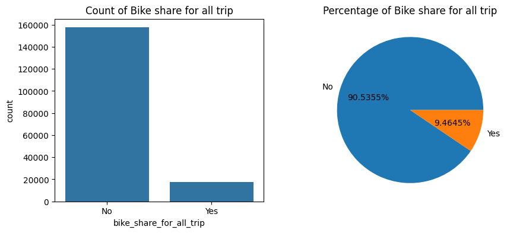

## Day Usage of Bike Share

Question: What days does the use of bike sharing services usually take place?

> Almost all users use bike sharing services on weekdays, and the number of users using bike sharing services on weekends is a half. The number of users using bike sharing services on Thursday is the largest, and the number of users using bike sharing services on Saturday is the smallest. So we should enhance more bikes on Thursday and provide more discounts on Saturday.

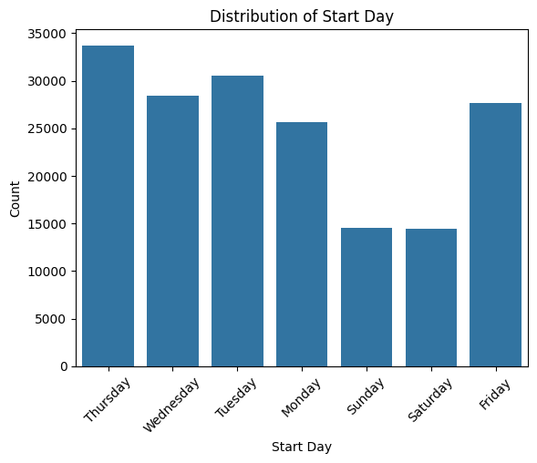

## Average Age, Gender of Bike Share Users

Question: What is user trends when using shared bikes?

> The average age of users using bike sharing services is 30 years old and almost of them are male. It's easy to understand younger people are more likely to use bike sharing services. So we should enhance more bikes in the area where young people live and work.

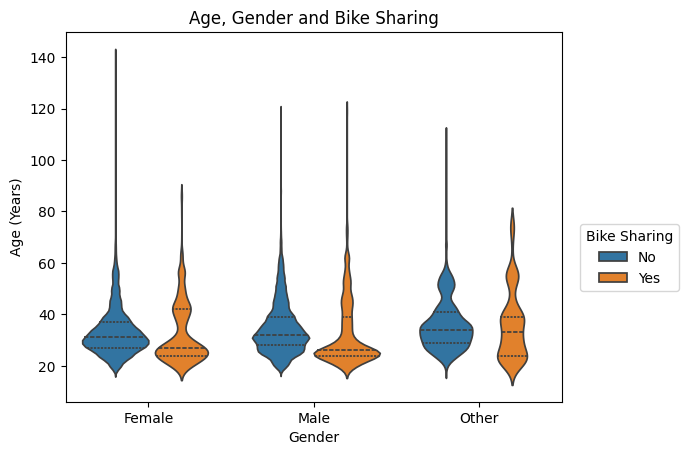